# survival lecture 2

Steve Simon

April 8, 2018

Lecture 2: The hazard function and the Cox proportional hazards regression model. The Cox proportional hazard model allows you to examine how categorical and continuous predictor variables influence survival data. You will review the definition of a hazard function, and interpret the meaning of constant hazard versus an increasing hazard or a decreasing hazard. Then you will fit Cox regression models and interpret the model coefficients.

```r
library(broom)
library(dplyr)
```

```r
library(ggplot2)
library(magrittr)
library(survival)
library(tidyr)
```

## Cox regression for gender

Recall that we ran a log rank test for gender using the WHAS100 data file. Let’s calculate a Cox regression model for the same data and compare it to the log rank test.

```r
fn <- "../../data/whas100.RData"
load(fn)
head(whas100)
```

```
##   id  admitdate    foldate los lenfol fstat age gender      bmi  time_yrs
## 1  1 03/13/1995 03/19/1995   4      6  Dead  65   Male 31.38134 0.0164271
## 2  2 01/14/1995 01/23/1996   5    374  Dead  88 Female 22.65790 1.0239562
## 3  3 02/17/1995 10/04/2001   5   2421  Dead  77   Male 27.87892 6.6283368
## 4  4 04/07/1995 07/14/1995   9     98  Dead  81 Female 21.47878 0.2683094
## 5  5 02/09/1995 05/29/1998   4   1205  Dead  78   Male 30.70601 3.2991102
## 6  6 01/16/1995 09/11/2000   7   2065  Dead  82 Female 26.45294 5.6536619
##   age_group
## 1     60-69
## 2      >=80
## 3     70-79
## 4      >=80
## 5     70-79
## 6      >=80
```

Always start with an overall Kaplan-Meier curve.

```r
table(whas100$fstat)
```

```
##
## Alive  Dead
##    49    51
```

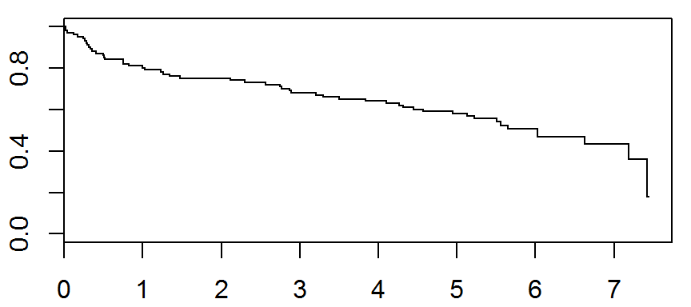

```r
par(mar=c(2.1, 2.1, 0.6, 0.6))
km_overall <- survfit(Surv(time_yrs, fstat=="Dead")~1, data=whas100)
plot(km_overall, conf.int=FALSE)
```

Now compare the Kaplan-Meier curves for males and females.

```r
table(whas100$gender, whas100$fstat)
```

```
##
##          Alive Dead
##   Male      37   28
##   Female    12   23
```

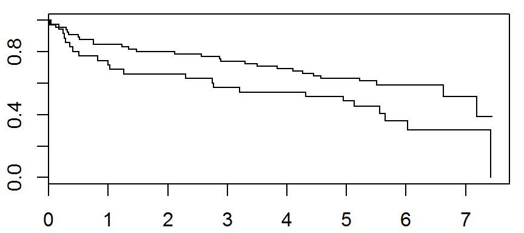

```r
par(mar=c(2.1, 2.1, 0.6, 0.6))
km_by_gender <-
  survfit(Surv(time_yrs, fstat=="Dead")~gender, data=whas100)
plot(km_by_gender)
```

Recall that you can put labels on this graph or produce a legend.

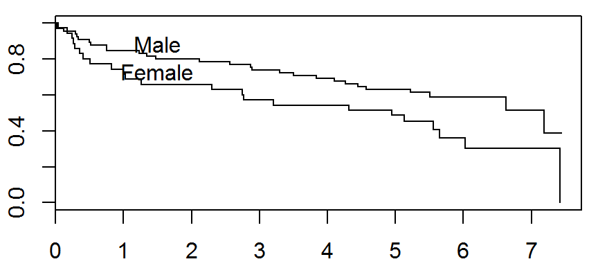

```r
par(mar=c(2.1, 2.1, 0.6, 0.6))
plot(km_by_gender)
km_by_gender                            %>%
  tidy                                  %>%
  filter(time > 1.5)                    %>%
  mutate(strata=sub(".*=", "", strata)) %>%
  group_by(strata)                      %>%
  summarize(y=first(estimate))          -> km_labels
text(1.5, km_labels$y+0.1, km_labels$strata)
```

Calculate the log rank test.

```r
survdiff(Surv(time_yrs, fstat=="Dead")~gender, data=whas100)
```

```
## Call:
## survdiff(formula = Surv(time_yrs, fstat == "Dead") ~ gender,
##     data = whas100)
##
##                N Observed Expected (O-E)^2/E (O-E)^2/V
## gender=Male   65       28     34.6      1.27      3.97
## gender=Female 35       23     16.4      2.68      3.97
##
##  Chisq= 4  on 1 degrees of freedom, p= 0.0463
```

Now you are ready for the Cox proportional hazards model.

Use coxph function to fit this model.

```r
cox_gender <- coxph(
  Surv(time_yrs, fstat=="Dead")~gender, data=whas100)
summary(cox_gender)
```

```
## Call:
## coxph(formula = Surv(time_yrs, fstat == "Dead") ~ gender, data = whas100)
##
##   n= 100, number of events= 51
##
##                coef exp(coef) se(coef)     z Pr(>|z|)
## genderFemale 0.5548    1.7416   0.2824 1.965   0.0494 *
## ---
## Signif. codes:  0 '***' 0.001 '**' 0.01 '*' 0.05 '.' 0.1 ' ' 1
##
##              exp(coef) exp(-coef) lower .95 upper .95
## genderFemale     1.742     0.5742     1.001     3.029
##
## Concordance= 0.565  (se = 0.035 )
## Rsquare= 0.037   (max possible= 0.985 )
## Likelihood ratio test= 3.75  on 1 df,   p=0.05293
## Wald test            = 3.86  on 1 df,   p=0.04945
## Score (logrank) test = 3.96  on 1 df,   p=0.04665
```

You can also export your Cox regression model to a data frame for further manipulation using the broom package. I am not using the augment function because it has issues with Cox regression.

```r
glance(cox_gender)
```

```
##     n nevent statistic.log p.value.log statistic.sc p.value.sc
## 1 100     51      3.746038  0.05293283     3.958093 0.04664651
##   statistic.wald p.value.wald  r.squared r.squared.max concordance
## 1           3.86   0.04944828 0.03676742     0.9847314   0.5653102
##   std.error.concordance    logLik      AIC      BIC
## 1            0.03512266 -207.2247 416.4493 418.3812
```

```r
tidy(cox_gender)
```

```
##           term  estimate std.error statistic    p.value    conf.low
## 1 genderFemale 0.5548116 0.2823892  1.964706 0.04944828 0.001339075
##   conf.high
## 1  1.108284
```

Instead of using augment, you can get estimates for the survival curves and the cumulative hazard using the survfit function.

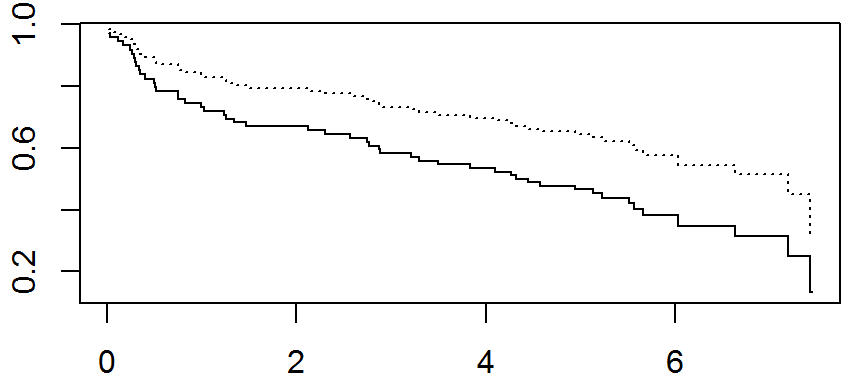

```r
par(mar=c(2.1, 2.1, 0.6, 0.6))
n <- data.frame(gender=factor(1:2, labels=c("Male", "Female")))
cox_predict <- survfit(cox_gender, newdata=n)
plot(
  cox_predict$time,
  cox_predict$surv[, 2], type="s")
lines(
  cox_predict$time,
  cox_predict$surv[, 1],
  type="s", lty="dotted")
```

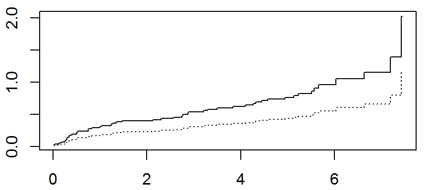

```r
plot(
  cox_predict$time,
  cox_predict$cumhaz[, 2], type="s")
lines(
  cox_predict$time,
  cox_predict$cumhaz[, 1],
  type="s", lty="dotted")
```

## Cox regression for age groups

Next let’s look at the age groups. Re-run the Kaplan-Meier curves and the logrank test for age groups before running a Cox regression model on age groups.

```r
par(mar=c(2.1, 2.1, 0.6, 0.6))
age_breaks <- c(0, 59, 69, 79, 99)
age_labels <- c("<60", "60-69", "70-79", ">=80")
whas100$age_group <- cut(whas100$age, age_breaks, age_labels)
table(whas100$age_group, whas100$fstat)
```

```
##
##         Alive Dead
##   <60      17    8
##   60-69    16    7
##   70-79     8   14
##   >=80      8   22
```

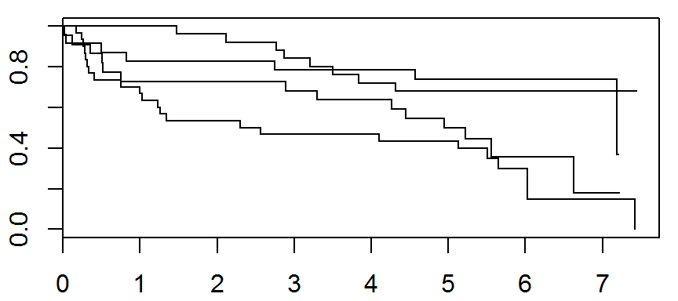

```r
par(mar=c(2.1, 2.1, 0.6, 0.6))
km_by_age_group <-
  survfit(Surv(time_yrs, fstat=="Dead")~age_group, data=whas100)
plot(km_by_age_group)
```

```r
survdiff(Surv(time_yrs, fstat=="Dead")~age_group, data=whas100)
```

```
## Call:
## survdiff(formula = Surv(time_yrs, fstat == "Dead") ~ age_group,
##     data = whas100)
##
##                  N Observed Expected (O-E)^2/E (O-E)^2/V
## age_group=<60   25        8     15.5      3.64      5.29
## age_group=60-69 23        7     12.9      2.71      3.68
## age_group=70-79 22       14     10.2      1.39      1.76
## age_group=>=80  30       22     12.3      7.57     10.18
##
##  Chisq= 15.6  on 3 degrees of freedom, p= 0.00139
```

Recall that if you want nice labels or a legend, you have to add a few things.

Compare the results below to Table 4.6.

```r
cox_age_group <-
  coxph(Surv(time_yrs, fstat=="Dead")~age_group, data=whas100)
print(cox_age_group)
```

```
## Call:
## coxph(formula = Surv(time_yrs, fstat == "Dead") ~ age_group,
##     data = whas100)
##
##                  coef exp(coef) se(coef)    z      p
## age_group60-69 0.0472    1.0484   0.5186 0.09 0.9274
## age_group70-79 0.9866    2.6820   0.4454 2.22 0.0267
## age_group>=80  1.2634    3.5373   0.4155 3.04 0.0024
##
## Likelihood ratio test=15.3  on 3 df, p=0.00155
## n= 100, number of events= 51
```

```r
summary(cox_age_group)
```

```
## Call:
## coxph(formula = Surv(time_yrs, fstat == "Dead") ~ age_group,
##     data = whas100)
##
##   n= 100, number of events= 51
##
##                   coef exp(coef) se(coef)     z Pr(>|z|)
## age_group60-69 0.04723   1.04836  0.51864 0.091  0.92745
## age_group70-79 0.98658   2.68204  0.44536 2.215  0.02675 *
## age_group>=80  1.26336   3.53730  0.41554 3.040  0.00236 **
## ---
## Signif. codes:  0 '***' 0.001 '**' 0.01 '*' 0.05 '.' 0.1 ' ' 1
##
##                exp(coef) exp(-coef) lower .95 upper .95
## age_group60-69     1.048     0.9539    0.3794     2.897
## age_group70-79     2.682     0.3729    1.1204     6.420
## age_group>=80      3.537     0.2827    1.5666     7.987
##
## Concordance= 0.636  (se = 0.042 )
## Rsquare= 0.142   (max possible= 0.985 )
## Likelihood ratio test= 15.33  on 3 df,   p=0.001553
## Wald test            = 14.02  on 3 df,   p=0.002882
## Score (logrank) test = 15.57  on 3 df,   p=0.00139
```

## Cox regression model for age as a continuous variable.

A big advantage of the Cox regression model is that it can treat age as a continuous variable. Here’s what that model produces. Compare the results below to Table 4.9.

```r
cox_age <-
  coxph(Surv(time_yrs, fstat=="Dead")~age, data=whas100)
summary(cox_age)
```

```
## Call:
## coxph(formula = Surv(time_yrs, fstat == "Dead") ~ age, data = whas100)
##
##   n= 100, number of events= 51
##
##        coef exp(coef) se(coef)     z Pr(>|z|)
## age 0.04567   1.04673  0.01195 3.822 0.000132 ***
## ---
## Signif. codes:  0 '***' 0.001 '**' 0.01 '*' 0.05 '.' 0.1 ' ' 1
##
##     exp(coef) exp(-coef) lower .95 upper .95
## age     1.047     0.9554     1.022     1.072
##
## Concordance= 0.664  (se = 0.043 )
## Rsquare= 0.159   (max possible= 0.985 )
## Likelihood ratio test= 17.36  on 1 df,   p=3.09e-05
## Wald test            = 14.61  on 1 df,   p=0.0001324
## Score (logrank) test = 15.64  on 1 df,   p=7.675e-05
```

When you include age as a continuous variable, the interpretation is similar to the interpretation of a continuous variable in linear regression.

The hazard ratio, 1.047, is the estimated relative change in the hazard when age increases by one unit. To get the relative change in the hazard when age increases by a decade, raise to the 10th power.

1.047^10 = 1.579

You can get the estimated survival probabilities and the estimated cumulative hazards at any value of age. Try doing this for ages 45, 65, and 85.

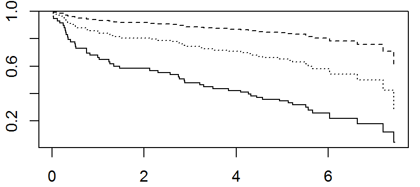

```r
par(mar=c(2.1, 2.1, 0.6, 0.6))
n <- data.frame(age=c(45, 65, 85))
cox_predict <- survfit(cox_age, newdata=n)
plot(
  cox_predict$time,
  cox_predict$surv[, 3], type="s")
lines(
  cox_predict$time,
  cox_predict$surv[, 2],
  type="s", lty="dotted")
lines(
  cox_predict$time,
  cox_predict$surv[, 1],
  type="s", lty="dashed")
```

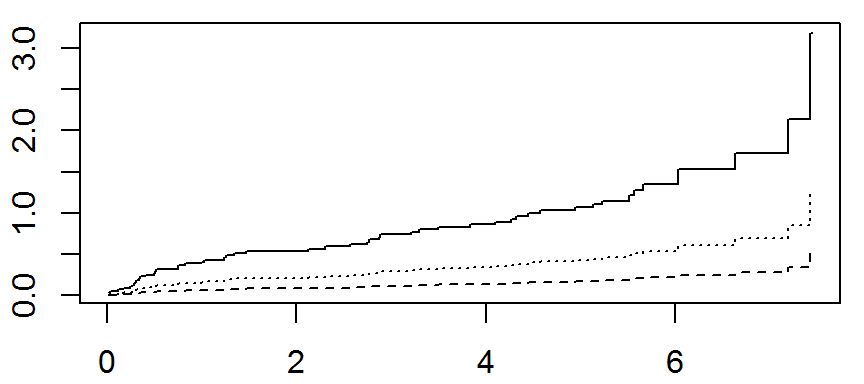

```r
plot(
  cox_predict$time,
  cox_predict$cumhaz[, 3], type="s")
lines(
  cox_predict$time,
  cox_predict$cumhaz[, 2],
  type="s", lty="dotted")
lines(
  cox_predict$time,
  cox_predict$cumhaz[, 1],
  type="s", lty="dashed")
```

Save everything for possible later re-use.

```r
save.image("../../data/class2.RData")
```